# Reproducible Research: Peer Assessment 1

Load library

```r
library("data.table")
```

```r
library(RColorBrewer)
library(ggplot2)
library(knitr)

opts_chunk$set(echo = TRUE, results = 'hold')
path <- getwd()
```

#Loada data

```r
data <- read.csv("activity.csv", header = TRUE, sep = ",", na.strings = "NA")
new_data <- na.omit(data)
```

```r
summary(data)
```

```
##      steps            date              interval
##  Min.   :  0.00   Length:17568       Min.   :   0.0
##  1st Qu.:  0.00   Class :character   1st Qu.: 588.8
##  Median :  0.00   Mode  :character   Median :1177.5
##  Mean   : 37.38                      Mean   :1177.5
##  3rd Qu.: 12.00                      3rd Qu.:1766.2
##  Max.   :806.00                      Max.   :2355.0
##  NA's   :2304
```

```r
str(data)
```

```
## 'data.frame':    17568 obs. of  3 variables:
##  $ steps   : int  NA NA NA NA NA NA NA NA NA NA ...
##  $ date    : chr  "2012-10-01" "2012-10-01" "2012-10-01" "2012-10-01" ...
##  $ interval: int  0 5 10 15 20 25 30 35 40 45 ...
```

## What is mean total number of steps taken per day?

1. Calculate the total number of steps taken per day

```r
daily<-c()  # This will be the total number of steps taken per day


for (i in 1:61){ # total number of days in October and November is 31+30=61
    start<-(i-1)*288+1  # 288 five-minute steps in a day; 24*60/5=288
    last<-(i-1)*288+288
    temp<-data[start:last,1]    # extracting all 5-minute steps for each day
    daily<-c(daily,sum(temp))   # concatenating the daily totals

     }
```

plot histograma

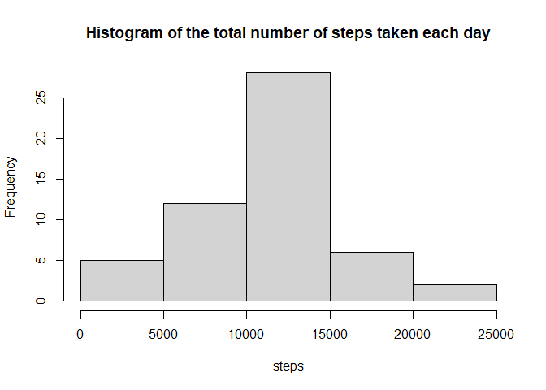

```r
daily_noNA<-daily[!is.na(daily)]  # 8 NA's are removed

hist(daily_noNA, xlab="steps",ylab="Frequency",
     main="Histogram of the total number of steps taken each day")
```

3. Calculate and report the mean and median of the total number of steps taken per day

```r
mean(daily,na.rm=T)
median(daily,na.rm=T)
```

```
## [1] 10766.19
## [1] 10765
```

## What is the average daily activity pattern?

1. Make a time series plot (i.e. 𝚝𝚢𝚙𝚎 = “𝚕”) of the 5-minute interval (x-axis) and the average number of steps taken, averaged across all days (y-axis)

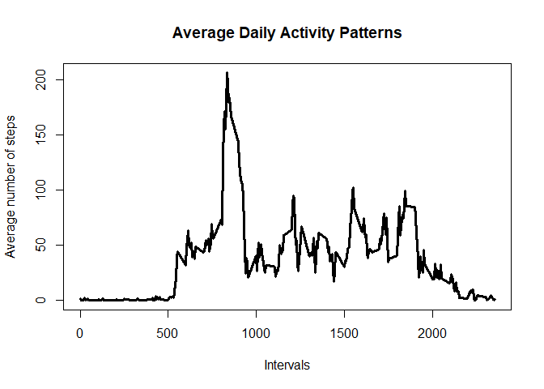

```r
x<-data[,1]         # number of steps in 5-minute intevals
y<-matrix(x,288,61) # so as to get average of 5-minute intevals across all days

five_average<-apply(y,1,mean,na.rm=TRUE)  # 5-minute interval average number of steps taken,
# averaged across all days

plot(data$interval[1:288],five_average, type='l',
     xlab='Intervals',lwd=3,
     ylab='Average number of steps',
     main ='Average Daily Activity Patterns')
```

2. Which 5-minute interval, on average across all the days in the dataset, contains the maximum number of steps?

```r
# find row id of maximum average number of steps in an interval
max_row_id <-which.max(five_average)

# get the interval with maximum average number of steps in an interval
interval_steps <- aggregate(steps ~ interval, new_data, mean)
interval_steps [max_row_id, ]
```

```
##     interval    steps
## 104      835 206.1698
```